# MTH 643: Problem Set 6

Jade Muyambo

2025-04-27

```r
library(tseries)
library(stats)
library(quantmod)
```

Question 1(a)

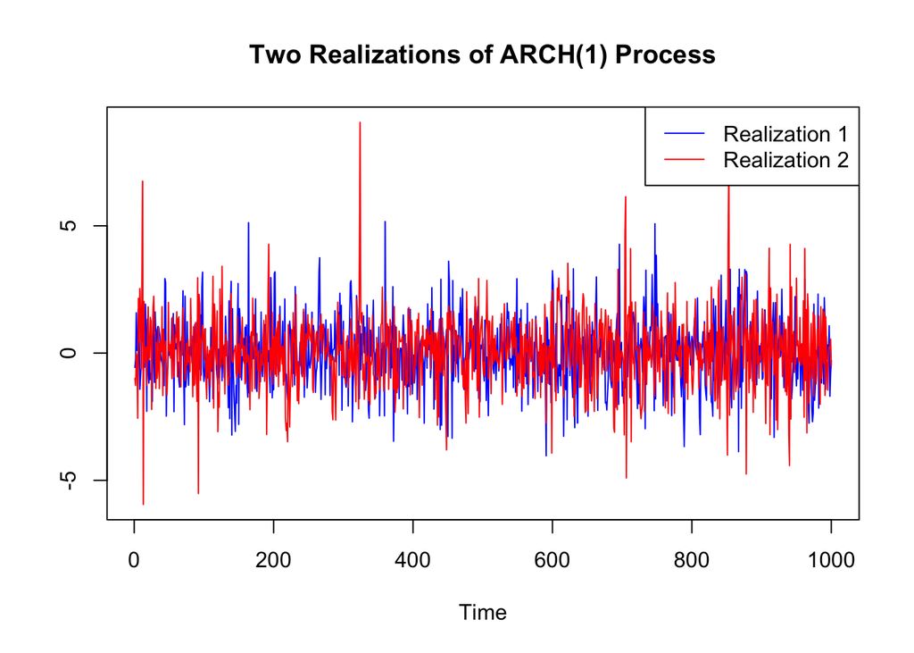

```r
set.seed(123)
n <- 1000
alpha <- 0.5

simulate_arch1 <- function(n, alpha) {
  x <- numeric(n)
  epsilon <- rnorm(n)
  x[1] <- epsilon[1]
  for (t in 2:n) {
    x[t] <- epsilon[t] * sqrt(1 + alpha * x[t-1]^2)
  }
  return(ts(x))
}

x1 <- simulate_arch1(n, alpha)
x2 <- simulate_arch1(n, alpha)

ts.plot(x1, x2, col = c("blue", "red"), main = "Two Realizations of ARCH(1) Process")
legend("topright", legend = c("Realization 1", "Realization 2"), col = c("blue", "red"), lty = 1)
```

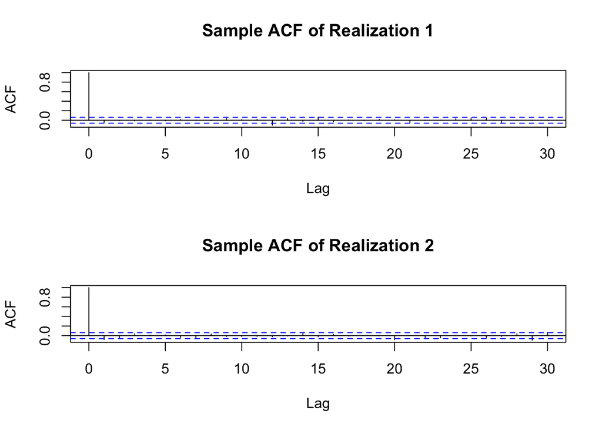

```r
par(mfrow = c(2,1))
acf(x1, main = "Sample ACF of Realization 1")
acf(x2, main = "Sample ACF of Realization 2")
```

```r
par(mfrow = c(1,1))
```

The two time series realizations of the ARCH(1) process show random movements around zero, but with occasional bursts of larger fluctuations. This changing volatility behavior is a typical feature of ARCH processes. Even though the mean stays close to zero overall, there are periods where the variability seems to get temporarily bigger. This happens because the variance depends on the previous value through the ARCH(1) structure, but the basic randomness still looks similar to white noise when just looking at the mean behavior.

When we look at the sample autocorrelation functions (ACFs) for each realization, the autocorrelations are very close to zero for almost all lags. This is what we expect for weak white noise. Although the process is conditionally heteroskedastic meaning the variance changes depending on the past, the values themselves are uncorrelated over time. Therefore, it’s true that the sample ACFs are consistent with the idea that the ARCH(1) process is weak white noise, meaning there is no strong pattern of correlation between different time points, even though the size of the fluctuations can cluster.

Question 1(b)

```r
box_test_x1 <- Box.test(x1, lag = 10, type = "Ljung")
box_test_x2 <- Box.test(x2, lag = 10, type = "Ljung")

box_test_x1
```

```
##
##  Box-Ljung test
##
## data:  x1
## X-squared = 4.4531, df = 10, p-value = 0.9246
```

```r
box_test_x2
```

```
##
##  Box-Ljung test
##
## data:  x2
## X-squared = 16.943, df = 10, p-value = 0.07563
```

The Ljung-Box test results show that for the first realization (x1), the p-value is very large (0.9246), meaning there is no evidence of autocorrelation, which strongly supports the idea that the process behaves like weak white noise. For the second realization (x2), the p-value is smaller (0.07563) but still greater than 0.05, so we also do not reject the white noise hypothesis at a typical 5% significance level. Overall, both realizations are consistent with weak white noise, as expected for an ARCH(1) process, although the second realization shows slightly more small sample variation.

Question 2(a)

```r
getSymbols(c("BAC", "JPM"), src = "yahoo", from = "2020-01-01", to = "2025-01-01")
```

```
## [1] "BAC" "JPM"
```

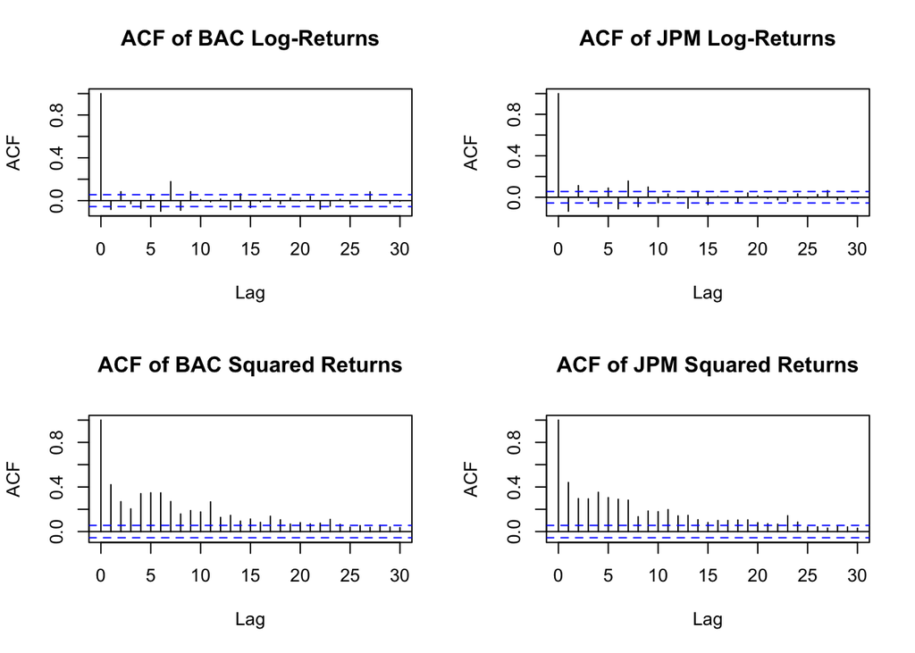

```r
BAC_logR <- diff(log(Ad(BAC)))
JPM_logR <- diff(log(Ad(JPM)))
BAC_logR <- na.omit(BAC_logR)
JPM_logR <- na.omit(JPM_logR)
logR <- cbind(BAC = BAC_logR, JPM = JPM_logR)

BAC_logR_sq <- BAC_logR^2
JPM_logR_sq <- JPM_logR^2

par(mfrow = c(2,2))
acf(BAC_logR, main = "ACF of BAC Log-Returns")
acf(JPM_logR, main = "ACF of JPM Log-Returns")
acf(BAC_logR_sq, main = "ACF of BAC Squared Returns")
acf(JPM_logR_sq, main = "ACF of JPM Squared Returns")
```

```r
par(mfrow = c(1,1))
```

The sample ACFs of the BAC and JPM log-returns show very little significant autocorrelation. Most of the spikes are small and fall within the blue dashed significance bands. This behavior is consistent with what we expect for financial asset returns, which are often modeled as weak white noise since their levels are essentially uncorrelated over time even though their volatility may change.

However, when we look at the ACFs of the squared log-returns, a different pattern emerges. Both BAC and JPM squared returns show noticeable autocorrelation that slowly decays over time. This suggests volatility clustering, meaning that periods of large movements tend to be followed by large movements, and periods of small movements tend to be followed by small movements. This behavior is typical for financial time series and indicates that although the returns themselves may not be autocorrelated, their variance (volatility) is autocorrelated, which motivates the use of models like ARCH and GARCH.

Question 2(b)

```r
box_bac <- Box.test(BAC_logR, lag = 10, type = "Ljung")
box_jpm <- Box.test(JPM_logR, lag = 10, type = "Ljung")
box_bac_sq <- Box.test(BAC_logR_sq, lag = 10, type = "Ljung")
box_jpm_sq <- Box.test(JPM_logR_sq, lag = 10, type = "Ljung")

box_bac
```

```
##
##  Box-Ljung test
##
## data:  BAC_logR
## X-squared = 99.293, df = 10, p-value < 2.2e-16
```

```r
box_jpm
```

```
##
##  Box-Ljung test
##
## data:  JPM_logR
## X-squared = 133.4, df = 10, p-value < 2.2e-16
```

```r
box_bac_sq
```

```
##
##  Box-Ljung test
##
## data:  BAC_logR_sq
## X-squared = 1025.9, df = 10, p-value < 2.2e-16
```

```r
box_jpm_sq
```

```
##
##  Box-Ljung test
##
## data:  JPM_logR_sq
## X-squared = 1049.5, df = 10, p-value < 2.2e-16
```

The Ljung-Box tests for the BAC and JPM log-returns both produced extremely small p-values, well below any typical significance level such as 5%. This result suggests that we reject the null hypothesis of no autocorrelation in the log-returns. Even though the ACF plots earlier did not show strong patterns, the large sample size makes even very small deviations statistically significant. Therefore, technically, there is some weak autocorrelation in the returns, although in practice the amount of dependence might be too small to matter for many applications.

For the squared returns, the Ljung-Box test results were even stronger. The test statistics were much larger, and the p-values again were extremely small. This provides clear evidence of strong autocorrelation in the squared returns, confirming the volatility clustering we observed in the ACF plots. This means that although returns themselves don’t have strong visible correlation, the size (or volatility) of the returns does show strong patterns over time, supporting the use of ARCH or GARCH-type models to better model the volatility behavior.

Question 3(b)

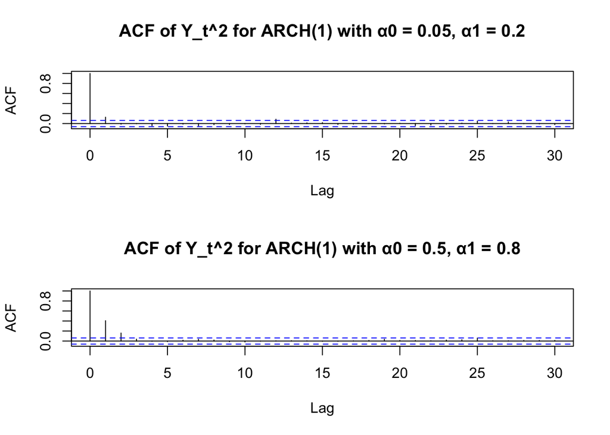

```r
set.seed(123)
n <- 1000

simulate_arch1 <- function(n, alpha0, alpha1) {
  Y <- numeric(n)
  sigma2 <- numeric(n)
  epsilon <- rnorm(n)

  sigma2[1] <- alpha0 / (1 - alpha1)
  Y[1] <- sqrt(sigma2[1]) * epsilon[1]

  for (t in 2:n) {
    sigma2[t] <- alpha0 + alpha1 * Y[t-1]^2
    Y[t] <- sqrt(sigma2[t]) * epsilon[t]
  }

  return(Y)
}

y1 <- simulate_arch1(n, alpha0 = 0.05, alpha1 = 0.2)
y2 <- simulate_arch1(n, alpha0 = 0.5, alpha1 = 0.8)

y1_sq <- y1^2
y2_sq <- y2^2

par(mfrow = c(2,1))
acf(y1_sq, main = "ACF of Y_t^2 for ARCH(1) with α0 = 0.05, α1 = 0.2")
acf(y2_sq, main = "ACF of Y_t^2 for ARCH(1) with α0 = 0.5, α1 = 0.8")
```

```r
par(mfrow = c(1,1))
```